# Zipcodes Financials Report #2

Ammar Ali

10/6/2020

# Background

Based of people’s income level, you can predict the percentage of what they will donate to charity. This report solely looks at Emgage Contributors’ Zipcodes. The following table is IRS data from 2014 used for this analysis:

|  | Income.Level | Percentage.of.Income.Donated | Total.Contacts.in.Each.Income.Level |
| --- | --- | --- | --- |
| 1 | &lt; $25k | 12.3% | 19 |
| 2 | $25k - $50k | 6.8% | 255 |
| 3 | $50k - $75k | 4.8% | 526 |
| 4 | $75k - $100k | 3.8% | 664 |
| 5 | $100k - $200k | 3% | 809 |
| 6 | $200k - $500k | 2.6% | 25 |

## Step 1: The Distribution of Incomes

The following is a histogram showing the distribution of the median income levels for contributing Zipcodes:

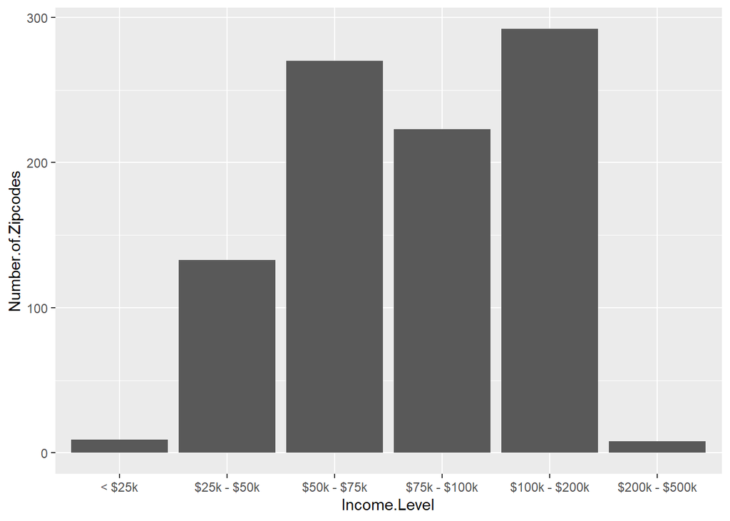

## Step 2: Determining Who Can Contribute More to Emgage

We will look at the number of contributions, the total contribution amounts, in comparison with the Median Income of their Zipcode

### Table 1: Contacts in $200K+ Income Bracket

|  | VANID | First Name | Last Name | Home City | Home State | Zipcode | Total Contribution Amount | Number Of Contributions | Total Contribution Amount Last Year | Total Number of Contributions Last Year | Median Household Income ($) | Estimated Donation Max ($) | Average Contribution ($) |
| --- | --- | --- | --- | --- | --- | --- | --- | --- | --- | --- | --- | --- | --- |
| 1 | 106677094 | Ariff | Cassim | Potomac | MD | 20854 | 500 | 1 | 0 | 0 | 206040 | 6181 | 500 |
| 2 | 108500075 | Ashiq | Munis | Great Falls | VA | 22066 | 50 | 1 | 0 | 0 | 223434 | 6703 | 50 |
| 3 | 104261079 | Nazir | Dossani | Great Falls | VA | 22066 | 100 | 2 | 0 | 0 | 223434 | 6703 | 50 |
| 4 | 106676370 | Ghulam | Mohiuddin | Potomac | MD | 20854 | 500 | 1 | 0 | 0 | 206040 | 6181 | 500 |
| 5 | 106724854 | Rehan A. | Dawer | Great Falls | VA | 22066 | 250 | 1 | 0 | 0 | 223434 | 6703 | 250 |
| 6 | 109923256 | Amir | Moghul | Danville | CA | 94506 | 100 | 1 | 0 | 0 | 205121 | 6154 | 100 |
| 7 | 108505879 | Amr | Razzak | Los Altos | CA | 94022 | 2000 | 2 | 1000 | 1 | 216042 | 6481 | 1000 |
| 8 | 104883279 | Umar | Rahman | Fairfax Station | VA | 22039 | 1700 | 2 | 0 | 0 | 210000 | 6300 | 850 |
| 9 | 108104817 | Mohammed | Barazi | Great Falls | VA | 22066 | 1000 | 1 | 0 | 0 | 223434 | 6703 | 1000 |
| 10 | 109062212 | Mir | Aamir | Danville | CA | 94506 | 100 | 1 | 100 | 1 | 205121 | 6154 | 100 |

[output cut: 15 more lines]

If you sort this table by Number of Contributions, you can see that majority of the contacts in this category have donated only 1, 2, or 3 times Emgage. From this category, I believe we ought to at strengthen relationships with those who gave three or fewer times as they live in the wealthiest zipcodes out of our database. **No contacts in this category have total contributions that exceed $3K**

### Table 2: Contacts in $200K+ Income Bracket with <= 3 Total Contributions

|  | VANID | First Name | Last Name | Home City | Home State | Zipcode | Total Contribution Amount | Number Of Contributions | Total Contribution Amount Last Year | Total Number of Contributions Last Year | Median Household Income ($) | Estimated Donation Max ($) | Average Contribution ($) |
| --- | --- | --- | --- | --- | --- | --- | --- | --- | --- | --- | --- | --- | --- |
| 1 | 106677094 | Ariff | Cassim | Potomac | MD | 20854 | 500 | 1 | 0 | 0 | 206040 | 6181 | 500 |
| 2 | 108500075 | Ashiq | Munis | Great Falls | VA | 22066 | 50 | 1 | 0 | 0 | 223434 | 6703 | 50 |
| 3 | 104261079 | Nazir | Dossani | Great Falls | VA | 22066 | 100 | 2 | 0 | 0 | 223434 | 6703 | 50 |
| 4 | 106676370 | Ghulam | Mohiuddin | Potomac | MD | 20854 | 500 | 1 | 0 | 0 | 206040 | 6181 | 500 |
| 5 | 106724854 | Rehan A. | Dawer | Great Falls | VA | 22066 | 250 | 1 | 0 | 0 | 223434 | 6703 | 250 |
| 6 | 109923256 | Amir | Moghul | Danville | CA | 94506 | 100 | 1 | 0 | 0 | 205121 | 6154 | 100 |
| 7 | 108505879 | Amr | Razzak | Los Altos | CA | 94022 | 2000 | 2 | 1000 | 1 | 216042 | 6481 | 1000 |
| 8 | 104883279 | Umar | Rahman | Fairfax Station | VA | 22039 | 1700 | 2 | 0 | 0 | 210000 | 6300 | 850 |
| 9 | 108104817 | Mohammed | Barazi | Great Falls | VA | 22066 | 1000 | 1 | 0 | 0 | 223434 | 6703 | 1000 |
| 10 | 109062212 | Mir | Aamir | Danville | CA | 94506 | 100 | 1 | 100 | 1 | 205121 | 6154 | 100 |

[output cut: 12 more lines]

### Table 3: Contacts in $100K-$200K Income Bracket Large Donors

Those with total donation amounts greater than $10K. A few board members in here.

|  | VANID | First Name | Last Name | Home City | Home State | Zipcode | Total Contribution Amount | Number Of Contributions | Total Contribution Amount Last Year | Total Number of Contributions Last Year | Median Household Income ($) | Estimated Donation Max ($) | Average Contribution ($) |
| --- | --- | --- | --- | --- | --- | --- | --- | --- | --- | --- | --- | --- | --- |
| 1 | 106051549 | Aisha | Sabar | New York | NY | 10024 | 14000 | 3 | 0 | 0 | 131668 | 3950 | 4667 |
| 2 | 104262149 | Mamdouh | Salama | Richmond | TX | 77406 | 49500 | 6 | 11000 | 2 | 116758 | 3503 | 8250 |
| 3 | 108585011 | Abdul | Chaudhri | Downingtown | PA | 19335 | 52839.08 | 18 | 30469.08 | 4 | 107686 | 3231 | 2936 |
| 4 | 104260645 | Wamiq | Sultan | Garnet Valley | PA | 19060 | 13500 | 3 | 5000 | 1 | 136971 | 4109 | 4500 |
| 5 | 105420657 | Abubakar | Sheikh | Bloomfield Hills | MI | 48302 | 20000 | 1 | 0 | 0 | 129154 | 3875 | 20000 |
| 6 | 104266131 | Doured | Daghastani | Pinecrest | FL | 33156 | 20500 | 7 | 5000 | 2 | 112373 | 3371 | 2929 |
| 7 | 105419994 | Iltefat | Hamzavi | Northville | MI | 48168 | 34860 | 38 | 4035 | 6 | 133984 | 4020 | 917 |
| 8 | 104260742 | Imran | Abbas | Ashburn | VA | 20147 | 11981.4 | 24 | 5742 | 14 | 130507 | 3915 | 499 |
| 9 | 107286028 | Asif | Ilyas | Wayne | PA | 19087 | 38650 | 8 | 10100 | 2 | 137943 | 4138 | 4831 |
| 10 | 104883189 | Ather | Anis | Leesburg | VA | 20176 | 13775 | 6 | 1000 | 1 | 128167 | 3845 | 2296 |

[output cut: 8 more lines]

### Table 4: Contacts in $100K-$200K Income Bracket w/o Large Donors

|  | VANID | First Name | Last Name | Home City | Home State | Zipcode | Total Contribution Amount | Number Of Contributions | Total Contribution Amount Last Year | Total Number of Contributions Last Year | Median Household Income ($) | Estimated Donation Max ($) | Average Contribution ($) |
| --- | --- | --- | --- | --- | --- | --- | --- | --- | --- | --- | --- | --- | --- |
| 1 | 106669411 | Reshma | Baig | Centreville | VA | 20120 | 100 | 2 | 0 | 0 | 122165 | 3665 | 50 |
| 2 | 108487193 | Jamil | Mohsin | Spring | TX | 77379 | 1500 | 1 | 1500 | 1 | 102008 | 3060 | 1500 |
| 3 | 108489701 | Michael | Gilbert | Falls Church | VA | 22043 | 1000 | 1 | 0 | 0 | 117182 | 3515 | 1000 |
| 4 | 109965409 | Azmat | Husain | Columbia | MD | 21046 | 1000 | 1 | 0 | 0 | 107081 | 3212 | 1000 |
| 5 | 106665466 | Tayyba | Anwar | Washington | DC | 20009 | 55 | 1 | 0 | 0 | 107128 | 3214 | 55 |
| 6 | 109314812 | Salim | Adaya | Santa Monica | CA | 90402 | 1000 | 1 | 1000 | 1 | 147111 | 4413 | 1000 |
| 7 | 109924062 | Ehab | El-Sharkawy | Murphy | TX | 75094 | 1 | 1 | 0 | 0 | 133125 | 3994 | 1 |
| 8 | 107504866 | Mohammed Asghar | Hussain | Upper Marlboro | MD | 20772 | 10 | 1 | 0 | 0 | 107838 | 3235 | 10 |
| 9 | 108331391 | Mary Ann | Espiritu | Austin | TX | 78701 | 100 | 1 | 100 | 1 | 107190 | 3216 | 100 |
| 10 | 104261814 | Ruth | Nasrullah | Houston | TX | 77059 | 25 | 1 | 25 | 1 | 134688 | 4041 | 25 |

[output cut: 781 more lines]

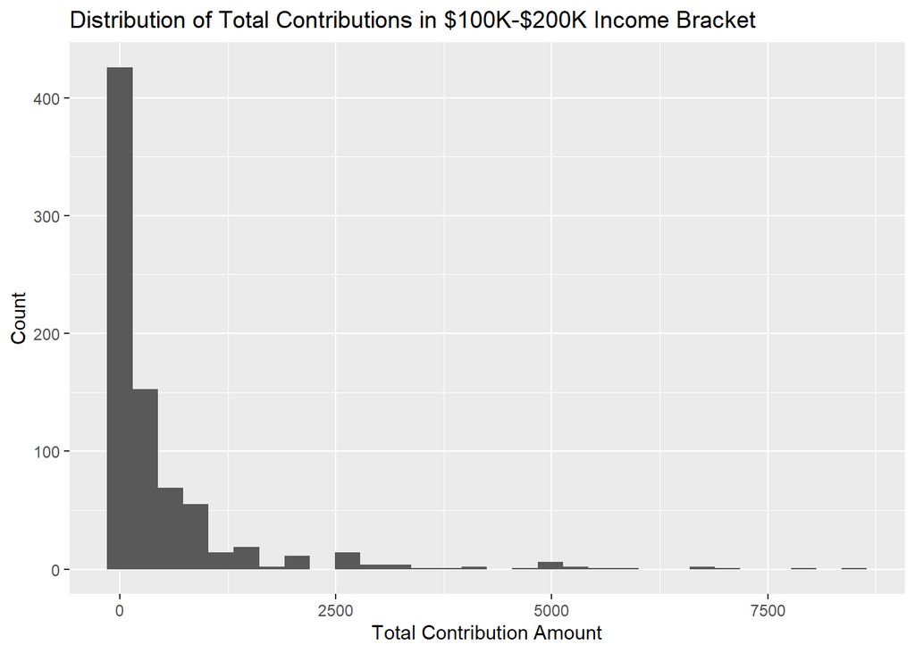

### Table 4.1: Contacts in $100K-200K Income Bracket w/ Total Contributions less than $2500

|  | VANID | First Name | Last Name | Home City | Home State | Zipcode | Total Contribution Amount | Number Of Contributions | Total Contribution Amount Last Year | Total Number of Contributions Last Year | Median Household Income ($) | Estimated Donation Max ($) | Average Contribution ($) |
| --- | --- | --- | --- | --- | --- | --- | --- | --- | --- | --- | --- | --- | --- |
| 1 | 106669411 | Reshma | Baig | Centreville | VA | 20120 | 100 | 2 | 0 | 0 | 122165 | 3665 | 50 |
| 2 | 108487193 | Jamil | Mohsin | Spring | TX | 77379 | 1500 | 1 | 1500 | 1 | 102008 | 3060 | 1500 |
| 3 | 108489701 | Michael | Gilbert | Falls Church | VA | 22043 | 1000 | 1 | 0 | 0 | 117182 | 3515 | 1000 |
| 4 | 109965409 | Azmat | Husain | Columbia | MD | 21046 | 1000 | 1 | 0 | 0 | 107081 | 3212 | 1000 |
| 5 | 106665466 | Tayyba | Anwar | Washington | DC | 20009 | 55 | 1 | 0 | 0 | 107128 | 3214 | 55 |
| 6 | 109314812 | Salim | Adaya | Santa Monica | CA | 90402 | 1000 | 1 | 1000 | 1 | 147111 | 4413 | 1000 |
| 7 | 109924062 | Ehab | El-Sharkawy | Murphy | TX | 75094 | 1 | 1 | 0 | 0 | 133125 | 3994 | 1 |
| 8 | 107504866 | Mohammed Asghar | Hussain | Upper Marlboro | MD | 20772 | 10 | 1 | 0 | 0 | 107838 | 3235 | 10 |
| 9 | 108331391 | Mary Ann | Espiritu | Austin | TX | 78701 | 100 | 1 | 100 | 1 | 107190 | 3216 | 100 |
| 10 | 104261814 | Ruth | Nasrullah | Houston | TX | 77059 | 25 | 1 | 25 | 1 | 134688 | 4041 | 25 |

[output cut: 745 more lines]

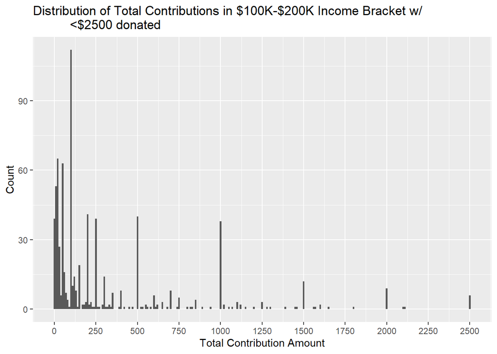

At least 600 people in this group have only given 1 time to Emgage. This group contains a large amount of one time small dollar contributors. **390 people in this group have** **given in total $100 or less to Emgage**. The average estimated donation max for this group is **$3830**.

### Table 5: Contacts in $75K - $100K Income Bracket Large Donors

|  | VANID | First Name | Last Name | Home City | Home State | Zipcode | Total Contribution Amount | Number Of Contributions | Total Contribution Amount Last Year | Total Number of Contributions Last Year | Median Household Income ($) | Estimated Donation Max ($) | Average Contribution ($) |
| --- | --- | --- | --- | --- | --- | --- | --- | --- | --- | --- | --- | --- | --- |
| 1 | 108063928 | Ibrahim | Al-Rashid | Miami | FL | 33131 | 112000 | 14 | 1000 | 1 | 88917 | 2668 | 8000 |
| 2 | 110374263 | Nishan | Khan | Sugar Land | TX | 77498 | 10250 | 3 | 150 | 1 | 79658 | 2390 | 3417 |
| 3 | 104261497 | Salman | Al-Rashid | New York | NY | 10019 | 15000 | 1 | 0 | 0 | 98833 | 2965 | 15000 |
| 4 | 104268658 | Nazar | Khan | Minneapolis | MN | 55409 | 31301 | 17 | 10025 | 3 | 76443 | 2293 | 1841 |
| 5 | 104260705 | Wasif | Qureshi | West Chester | PA | 19382 | 22070 | 13 | 7000 | 2 | 96998 | 2910 | 1698 |
| 6 | 104261448 | Khurrum | Wahid | Coral Springs | FL | 33071 | 11902.74 | 17 | 5596.74 | 3 | 89440 | 2683 | 700 |
| 7 | 104260395 | Muzammil | Ahmed | Canton | MI | 48187 | 19201 | 13 | 9500 | 4 | 84161 | 2525 | 1477 |
| 8 | 104261560 | Shahid | Usmani | Orlando | FL | 32836 | 26285 | 9 | 10015 | 3 | 91060 | 2732 | 2921 |

### Table 6: Contacts in $75K-$100K Income Bracket w/o Large Donors

|  | VANID | First Name | Last Name | Home City | Home State | Zipcode | Total Contribution Amount | Number Of Contributions | Total Contribution Amount Last Year | Total Number of Contributions Last Year | Median Household Income ($) | Estimated Donation Max ($) | Average Contribution ($) |
| --- | --- | --- | --- | --- | --- | --- | --- | --- | --- | --- | --- | --- | --- |
| 1 | 106669520 | Zehra | Zaidi | Germantown | MD | 20876 | 250 | 1 | 0 | 0 | 94891 | 2847 | 250 |
| 2 | 104260209 | Sameer | Shamsi | New York | NY | 10001 | 1001 | 2 | 0 | 0 | 88526 | 2656 | 500 |
| 3 | 108345539 | Michelle | Settles | Austin | TX | 78731 | 100 | 1 | 100 | 1 | 94048 | 2821 | 100 |
| 4 | 108487168 | Fayyaz | Shah | Austin | TX | 78749 | 50 | 1 | 50 | 1 | 98953 | 2969 | 50 |
| 5 | 109966983 | Khalid | Touati | Irving | TX | 75063 | 20 | 1 | 0 | 0 | 91431 | 2743 | 20 |
| 6 | 106928930 | Amajid | Khan | Canton | MI | 48188 | 75 | 3 | 25 | 1 | 98562 | 2957 | 25 |
| 7 | 106552833 | Saabreen | Ahmed | Sugar Land | TX | 77498 | 25 | 1 | 0 | 0 | 79658 | 2390 | 25 |
| 8 | 106564951 | Subhana | Ahmed | Sugar Land | TX | 77498 | 25 | 1 | 0 | 0 | 79658 | 2390 | 25 |
| 9 | 106628355 | Asgharali | Kazi | Oviedo | FL | 32765 | 100 | 2 | 50 | 1 | 77074 | 2312 | 50 |
| 10 | 109924798 | Saquib | Rahim | New York | NY | 10019 | 1000 | 1 | 0 | 0 | 98833 | 2965 | 1000 |

[output cut: 646 more lines]

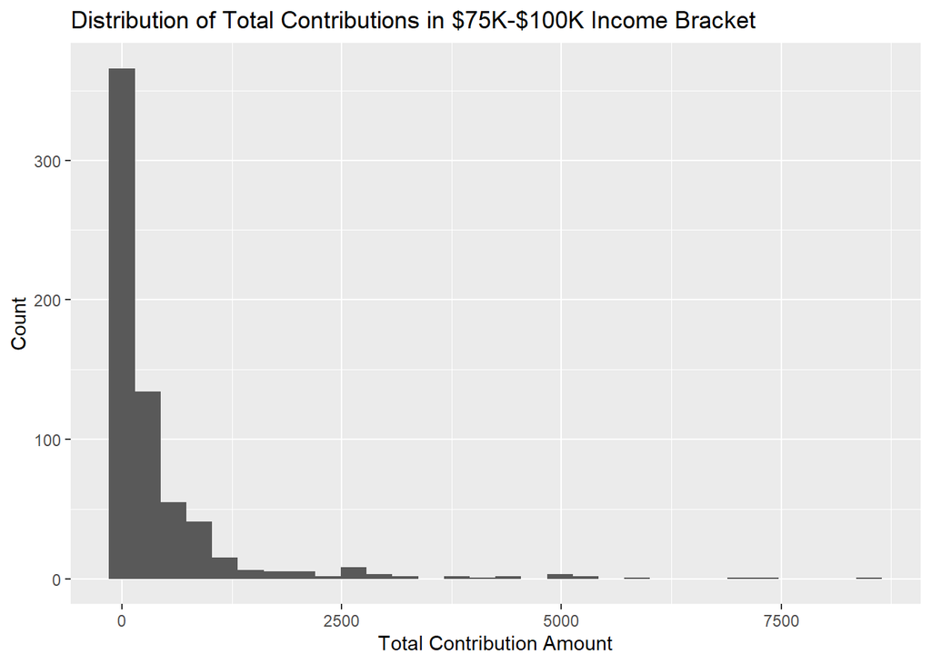

**629** contacts from this income bracket have given less than $2500 to Emgage. At least 500 of the contacts in this group have given 1 time to Emgage

### Table 6.1 Contacts in $75K-$100K Income Bracket w/ Total Contributions less than $2500

|  | VANID | First Name | Last Name | Home City | Home State | Zipcode | Total Contribution Amount | Number Of Contributions | Total Contribution Amount Last Year | Total Number of Contributions Last Year | Median Household Income ($) | Estimated Donation Max ($) | Average Contribution ($) |
| --- | --- | --- | --- | --- | --- | --- | --- | --- | --- | --- | --- | --- | --- |
| 1 | 106669520 | Zehra | Zaidi | Germantown | MD | 20876 | 250 | 1 | 0 | 0 | 94891 | 2847 | 250 |
| 2 | 104260209 | Sameer | Shamsi | New York | NY | 10001 | 1001 | 2 | 0 | 0 | 88526 | 2656 | 500 |
| 3 | 108345539 | Michelle | Settles | Austin | TX | 78731 | 100 | 1 | 100 | 1 | 94048 | 2821 | 100 |
| 4 | 108487168 | Fayyaz | Shah | Austin | TX | 78749 | 50 | 1 | 50 | 1 | 98953 | 2969 | 50 |
| 5 | 109966983 | Khalid | Touati | Irving | TX | 75063 | 20 | 1 | 0 | 0 | 91431 | 2743 | 20 |
| 6 | 106928930 | Amajid | Khan | Canton | MI | 48188 | 75 | 3 | 25 | 1 | 98562 | 2957 | 25 |
| 7 | 106552833 | Saabreen | Ahmed | Sugar Land | TX | 77498 | 25 | 1 | 0 | 0 | 79658 | 2390 | 25 |
| 8 | 106564951 | Subhana | Ahmed | Sugar Land | TX | 77498 | 25 | 1 | 0 | 0 | 79658 | 2390 | 25 |
| 9 | 106628355 | Asgharali | Kazi | Oviedo | FL | 32765 | 100 | 2 | 50 | 1 | 77074 | 2312 | 50 |
| 10 | 109924798 | Saquib | Rahim | New York | NY | 10019 | 1000 | 1 | 0 | 0 | 98833 | 2965 | 1000 |

[output cut: 619 more lines]

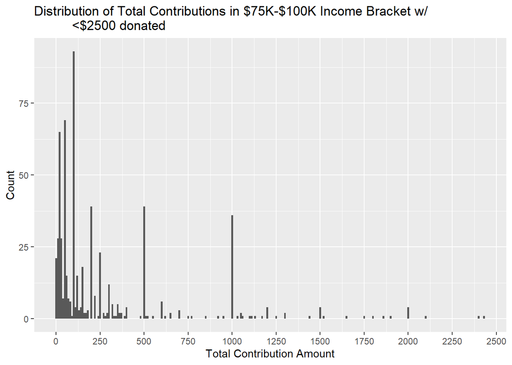

**338** people in this group have donated $100 or less to Emgage. The average estimated donation max for this group is **$2717**.